# SMEA 586: Problem Set 3

Brian McGreal

May 17, 2024

Over the next decade, massive investments in fish passage improvements will be made in the Pacific Northwest. Despite this, however, available financial resources fall extremely short of what would be needed to remove all blockages to fish passage. Thus, it is critical to ensure investment dollars are targeted to those projects that deliver the most high-quality salmon habitat.

However, it is often difficult to estimate habitat gains from barrier correction projects due to unknown barriers in the system. In this problem set, we’ll look at the problem of unknown or hidden barriers in Snohomish county. Specifically, we will define a hidden barrier to exist anytime there is not a recorded fish passage barrier within 50 feet of a road/stream intersection.

The goal of the problem set is to create a bivariate choropleth map demonstrating variability in the number of crossings without a documented fish passage barrier per square kilometer (AreaSqKm) and variability in the number fish passage barriers per square kilometer (AreaSqKm) across HUC 12 (watersheds) in Snohomish county. Make sure your figure does not show information for space outside of Snohomish county (and you can choose how you want to do this).

Note that although we don’t cover bivariate choropleth maps until Section 8 of the class, you can do ~90% of the work on this problem set with tools learned in Section 6.

The 5 datasets you will use are:

1. A (https://rdrr.io/cran/tigris/man/roads.html)[roads dataset] for Snohomish County.
2. The (https://wdfw.wa.gov/species-habitats/habitat-recovery/fish-passage/assessment)[WDFW Fish passage inventory] generated on the day you first download it (or subsequently update it by deleting from your data folder and downloading it again).
3. The boundaries of Snohomish County.
4. The (https://www.usgs.gov/national-hydrography/nhdplus-high-resolution)[USGS NHDPlus HR dataset].
5. The boundaries of HUC12s within our study region. Note the HUC12s are uniquely identified by the NHDPlusID variable.

```r
# +
```

# 1 Load data

```r
roads <- tigris::roads("Washington", "Snohomish", year = 2023)

if(!file.exists(here("data", "WdfwFishPassage.zip"))){
  download.file(
    "https://fortress.wa.gov/dfw/public/PublicDownload/habitat/FishPassage/WdfwFishPassage.zip",
    here("data", "WdfwFishPassage.zip")
  )
  unzip(
    here("data", "WdfwFishPassage.zip"),
    exdir = here("data", "WdfwFishPassage")
  )
} else {
  message(paste0("WDFW Inventory already present. Last downloaded ", file.info(here("data", "fish_pass_invs", "WdfwFishPassage.zip"))$mtime, "."))
}
```

```
## WDFW Inventory already present. Last downloaded NA.
```

```r
wdfw_inv <-
  st_read(
    here("data", "WdfwFishPassage", "WdfwFishPassage.gdb"),
    layer = "WDFW_FishPassageSite"
  )
snohomish <- tigris::counties("Washington", year = 2023) %>%
  filter(NAME == "Snohomish")

streams <-
  read_sf(
    here("data", "ps3_dat", "NHD1711", "NHDPLUS_H_1711_HU4_GDB.gdb"),
    # Include core flowline data, catchment data, and WDB HUC boundaries
    layer = "NHDFlowline"
  ) %>%
  st_zm()

huc12s <-
  read_sf(
    here("data", "ps3_dat", "NHD1711", "NHDPLUS_H_1711_HU4_GDB.gdb"),
    # Include core flowline data, catchment data, and WDB HUC boundaries
    layer = "WBDHU12"
  )
# subset data
# check classes
class(roads)
```

```
## [1] "sf"         "data.frame"
```

```r
class(snohomish)
```

```
## [1] "sf"         "data.frame"
```

```r
class(streams)
```

```
## [1] "sf"         "tbl_df"     "tbl"        "data.frame"
```

```r
class(wdfw_inv)
```

```
## [1] "sf"         "data.frame"
```

```r
class(huc12s)
```

```
## [1] "sf"         "tbl_df"     "tbl"        "data.frame"
```

```r
# subset three of four
snohomish_roads <- roads %>% st_filter(., y = snohomish)
snohomish_streams <- streams %>% st_filter(., y = snohomish)
snohomish_huc12s <- huc12s %>% st_filter(., y = snohomish)

# crs don't match for these guys
st_crs(snohomish)
```

```
## Coordinate Reference System:
##   User input: NAD83
##   wkt:
## GEOGCRS["NAD83",
##     DATUM["North American Datum 1983",
##         ELLIPSOID["GRS 1980",6378137,298.257222101,
##             LENGTHUNIT["metre",1]]],
##     PRIMEM["Greenwich",0,
##         ANGLEUNIT["degree",0.0174532925199433]],
##     CS[ellipsoidal,2],
##         AXIS["latitude",north,
##             ORDER[1],
##             ANGLEUNIT["degree",0.0174532925199433]],
##         AXIS["longitude",east,
##             ORDER[2],
##             ANGLEUNIT["degree",0.0174532925199433]],
##     ID["EPSG",4269]]
```

```r
st_crs(wdfw_inv)
```

```
## Coordinate Reference System:
##   User input: NAD83(HARN) / Washington South
##   wkt:
## PROJCRS["NAD83(HARN) / Washington South",
##     BASEGEOGCRS["NAD83(HARN)",
##         DATUM["NAD83 (High Accuracy Reference Network)",
##             ELLIPSOID["GRS 1980",6378137,298.257222101,
##                 LENGTHUNIT["metre",1]]],
##         PRIMEM["Greenwich",0,
##             ANGLEUNIT["degree",0.0174532925199433]],
##         ID["EPSG",4152]],
##     CONVERSION["SPCS83 Washington South zone (meter)",
##         METHOD["Lambert Conic Conformal (2SP)",
##             ID["EPSG",9802]],
##         PARAMETER["Latitude of false origin",45.3333333333333,
##             ANGLEUNIT["degree",0.0174532925199433],
##             ID["EPSG",8821]],
##         PARAMETER["Longitude of false origin",-120.5,
##             ANGLEUNIT["degree",0.0174532925199433],
##             ID["EPSG",8822]],
##         PARAMETER["Latitude of 1st standard parallel",47.3333333333333,
##             ANGLEUNIT["degree",0.0174532925199433],
##             ID["EPSG",8823]],
##         PARAMETER["Latitude of 2nd standard parallel",45.8333333333333,
##             ANGLEUNIT["degree",0.0174532925199433],
##             ID["EPSG",8824]],
##         PARAMETER["Easting at false origin",500000,
##             LENGTHUNIT["metre",1],
##             ID["EPSG",8826]],
##         PARAMETER["Northing at false origin",0,
##             LENGTHUNIT["metre",1],
##             ID["EPSG",8827]]],
##     CS[Cartesian,2],
##         AXIS["easting (X)",east,
##             ORDER[1],
##             LENGTHUNIT["metre",1]],
##         AXIS["northing (Y)",north,
##             ORDER[2],
##             LENGTHUNIT["metre",1]],
##     USAGE[
##         SCOPE["Engineering survey, topographic mapping."],
##         AREA["United States (USA) - Washington - counties of Adams; Asotin; Benton; Clark; Columbia; Cowlitz; Franklin; Garfield; Grant south of approximately 47°30'N; Grays Harbor; Kittitas; Klickitat; Lewis; Mason; Pacific; Pierce; Skamania; Thurston; Wahkiakum; Walla Walla; Whitman; Yakima."],
##         BBOX[45.54,-124.4,47.61,-116.91]],
##     ID["EPSG",2856]]
```

```r
snohomish <- st_transform(snohomish, crs = 2856)
st_crs(snohomish)
```

```
## Coordinate Reference System:
##   User input: EPSG:2856
##   wkt:
## PROJCRS["NAD83(HARN) / Washington South",
##     BASEGEOGCRS["NAD83(HARN)",
##         DATUM["NAD83 (High Accuracy Reference Network)",
##             ELLIPSOID["GRS 1980",6378137,298.257222101,
##                 LENGTHUNIT["metre",1]]],
##         PRIMEM["Greenwich",0,
##             ANGLEUNIT["degree",0.0174532925199433]],
##         ID["EPSG",4152]],
##     CONVERSION["SPCS83 Washington South zone (meter)",
##         METHOD["Lambert Conic Conformal (2SP)",
##             ID["EPSG",9802]],
##         PARAMETER["Latitude of false origin",45.3333333333333,
##             ANGLEUNIT["degree",0.0174532925199433],
##             ID["EPSG",8821]],
##         PARAMETER["Longitude of false origin",-120.5,
##             ANGLEUNIT["degree",0.0174532925199433],
##             ID["EPSG",8822]],
##         PARAMETER["Latitude of 1st standard parallel",47.3333333333333,
##             ANGLEUNIT["degree",0.0174532925199433],
##             ID["EPSG",8823]],
##         PARAMETER["Latitude of 2nd standard parallel",45.8333333333333,
##             ANGLEUNIT["degree",0.0174532925199433],
##             ID["EPSG",8824]],
##         PARAMETER["Easting at false origin",500000,
##             LENGTHUNIT["metre",1],
##             ID["EPSG",8826]],
##         PARAMETER["Northing at false origin",0,
##             LENGTHUNIT["metre",1],
##             ID["EPSG",8827]]],
##     CS[Cartesian,2],
##         AXIS["easting (X)",east,
##             ORDER[1],
##             LENGTHUNIT["metre",1]],
##         AXIS["northing (Y)",north,
##             ORDER[2],
##             LENGTHUNIT["metre",1]],
##     USAGE[
##         SCOPE["Engineering survey, topographic mapping."],
##         AREA["United States (USA) - Washington - counties of Adams; Asotin; Benton; Clark; Columbia; Cowlitz; Franklin; Garfield; Grant south of approximately 47°30'N; Grays Harbor; Kittitas; Klickitat; Lewis; Mason; Pacific; Pierce; Skamania; Thurston; Wahkiakum; Walla Walla; Whitman; Yakima."],
##         BBOX[45.54,-124.4,47.61,-116.91]],
##     ID["EPSG",2856]]
```

```r
# final subset
snohomish_wdfw_inv <- wdfw_inv %>% st_filter(., y = snohomish)

class(snohomish_roads)
```

```
## [1] "sf"         "data.frame"
```

```r
class(snohomish_streams)
```

```
## [1] "sf"         "tbl_df"     "tbl"        "data.frame"
```

```r
class(snohomish_wdfw_inv)
```

```
## [1] "sf"         "data.frame"
```

```r
class(snohomish_huc12s)
```

```
## [1] "sf"         "tbl_df"     "tbl"        "data.frame"
```

```r
snohomish_roads <- st_transform(snohomish_roads, crs = 2856)
snohomish_streams <- st_transform(snohomish_streams, crs = 2856)
snohomish_wdfw_inv <- st_transform(snohomish_wdfw_inv, crs = 2856)
snohomish_huc12s <- st_transform(snohomish_huc12s, crs = 2856)

# let's see if we can find intersecting roads and streams
snohomish_intersections <- st_intersection(snohomish_streams, snohomish_roads)
snohomish_intersections <- st_as_sf(x = snohomish_intersections)
class(snohomish_intersections)
```

```
## [1] "sf"         "tbl_df"     "tbl"        "data.frame"
```

```r
# create ID for intersections
snohomish_intersections <- tibble::rowid_to_column(snohomish_intersections, "ID")

# define known barriers
z <- st_join(snohomish_intersections, snohomish_wdfw_inv, st_is_within_distance, dist = 15.24)
snohomish_unknown <- z %>% filter_at(vars(SiteRecordID), all_vars(is.na(.)))

# see how it goes together
# ptm <- proc.time()
# test <- ggplot() +
#   geom_sf(data = snohomish_huc12s) +
#   geom_sf(data = snohomish_streams, color = "blue", alpha = 0.2) +
#   geom_sf(data = snohomish_roads, color = "yellow", alpha = 0.2) +
#   geom_sf(data = snohomish_wdfw_inv, color = "green", alpha = 0.05) +
#   geom_sf(data = snohomish_unknown, color = "red", alpha = 0.05)
# test
# proc.time() - ptm

# counting points per huc12
CountPointsInPolygons <- function(pts, polygons){
  countPts = c()
  for (i in 1:nrow(polygons)) {
    polySelect <- polygons[i,]
    pts2 <- st_intersection(pts, polySelect)
    countPts[i] = nrow(pts2)

  }

  return(cbind(polygons,countPts))
}

huc12s_intersections <- CountPointsInPolygons(snohomish_intersections, snohomish_huc12s)
```

[output not shown]

[output cut: 97 more lines]

[output not shown]

```r
huc12s_intersections <- huc12s_intersections %>%
  rename(intersectionPts = countPts)

huc12s_unknown <- CountPointsInPolygons(snohomish_unknown, snohomish_huc12s)
```

[output not shown]

[output cut: 99 more lines]

[output not shown]

```r
huc12s_unknown <- huc12s_unknown %>%
  rename(hiddenPts = countPts)

huc12s_unknownJOIN <- as.data.frame(cbind(huc12s_unknown$TNMID, huc12s_unknown$hiddenPts))

huc12s_unknownJOIN <- huc12s_unknownJOIN %>%
  rename(hiddenPts = V2)
huc12s_unknownJOIN <- huc12s_unknownJOIN %>%
  rename(TNMID = V1)

class(huc12s_intersections)
```

```
## [1] "sf"         "data.frame"
```

```r
class(huc12s_unknownJOIN)
```

```
## [1] "data.frame"
```

```r
# join them data sets
huc12s_barriers <- full_join(huc12s_intersections, huc12s_unknownJOIN, by = "TNMID")
huc12s_barriers <- transform(huc12s_barriers, hiddenPts = as.numeric(hiddenPts))

# bivariate chloropleth?
summary(huc12s_barriers$intersectionPts)
```

```
##    Min. 1st Qu.  Median    Mean 3rd Qu.    Max.
##     0.0    24.0    90.0   105.7   160.0   539.0
```

```r
summary(huc12s_barriers$hiddenPts)
```

```
##    Min. 1st Qu.  Median    Mean 3rd Qu.    Max.
##    0.00   20.00   80.00   90.42  123.00  441.00
```

```r
huc12s_barriers$intersectionPts_scaled <- (huc12s_barriers$intersectionPts/huc12s_barriers$AreaSqKm)
huc12s_barriers$hiddenPts_scaled <- (huc12s_barriers$hiddenPts/huc12s_barriers$AreaSqKm)

huc12s_barriers <- st_transform(huc12s_barriers, crs = 2856)
bivch_dat <- bi_class(
  huc12s_barriers,
  x = intersectionPts_scaled,
  y = hiddenPts_scaled,
  style = "quantile",
  dim = 4
)

bivch_dat <- st_intersection(snohomish, bivch_dat)
```

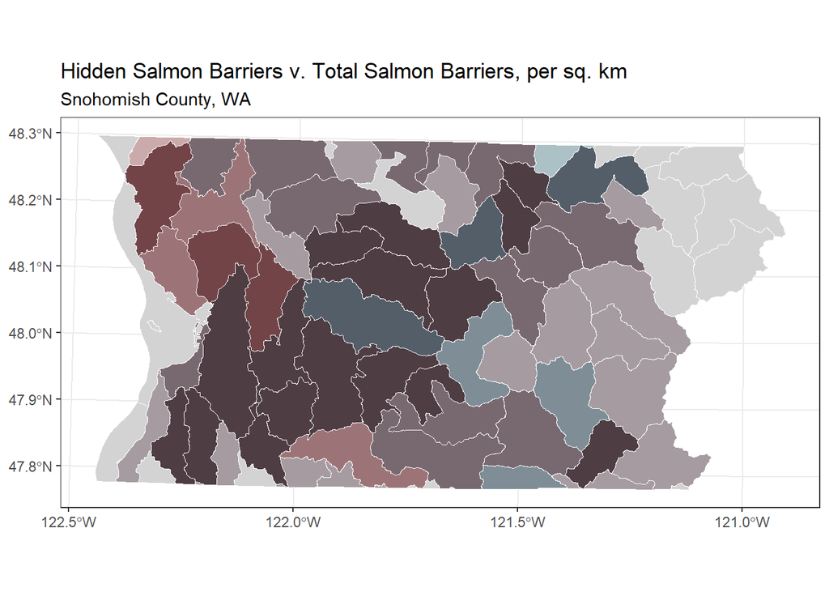

```r
bivch_map <- ggplot() +
  geom_sf(
    data = bivch_dat,
    mapping = aes(fill = bi_class),
    color = "white",
    show.legend = FALSE
  ) +
  bi_scale_fill(pal = "GrPink2", dim = 4) +
  labs(title = "Hidden Salmon Barriers v. Total Salmon Barriers, per sq. km", subtitle = "Snohomish County, WA") +
  theme_bw()
bivch_map
```

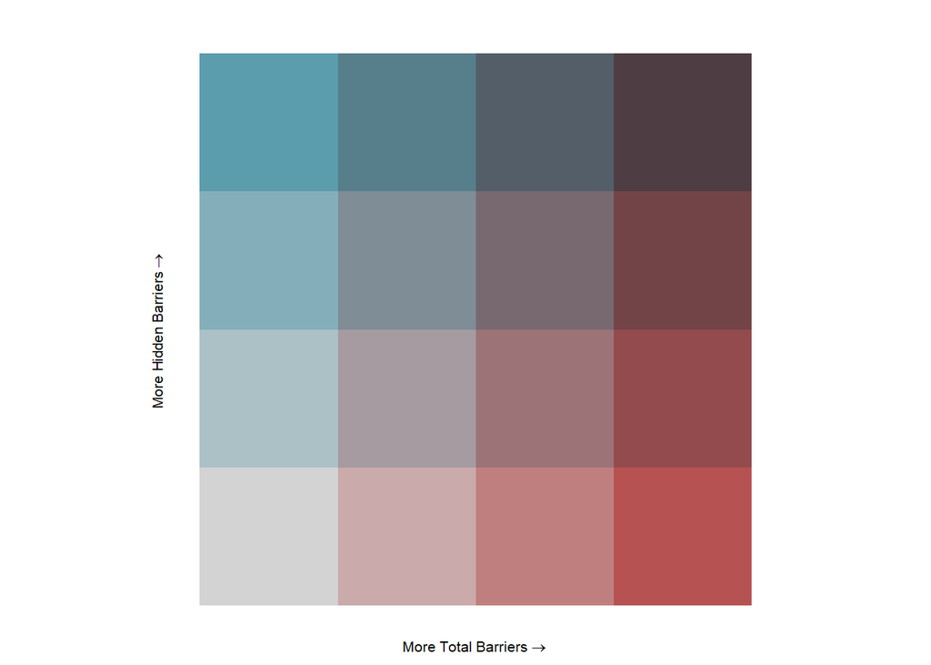

```r
bivch_leg <- bi_legend(
  pal = "GrPink2",
  dim = 4,
  xlab = "More Total Barriers",
  ylab = "More Hidden Barriers",
  size = 8
)
bivch_leg
```

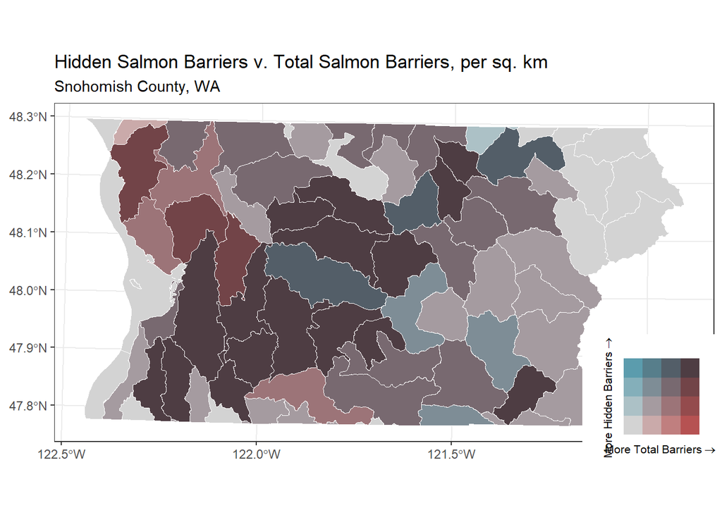

```r
bi_chloropleth <- ggdraw() +
  draw_plot(bivch_map, 0, 0, 1, 1) +
  draw_plot(bivch_leg, 0.78, 0.1, 0.25, 0.25)
bi_chloropleth
```

```r
# snohomish_huc12sISSUE <- st_transform(snohomish_huc12s, crs = 4269)
# snohomishISSUE <- st_transform(snohomish, crs = 4269)
# issue <- ggplot() +
#   geom_sf(data = snohomish_huc12sISSUE) +
#   geom_sf(data = snohomishISSUE, color = "red", alpha = 0.05)
# issue
```